# The Divide in Chicago

DJ Lee

## The Racial Divide

The racial divide in Chicago has never really been a secret. However, the origin story to this divide may not be as commonly known. The roots of the racial divide, like many large cities across the United States, are no accident and can be traced back to federal regulation and policy. As the African American population began to grow in the early 20th century, they began to face housing and real estate practices that were totally racist. Redlining occurred across the country and particularly in Chicago allowing banks to refuse home loans to black families, especially in good neighborhoods. Federal regulation pushed white families into suburban neighborhoods and black families into urban areas.

Today these racial implications still exist. If you mention the north side of Chicago to anybody familiar with the area, you are implicitly speaking about the white side of Chicago. Contrarily, when mentioning the south side of Chicago, you are implicitly speaking about the black side of Chicago. These implications have become almost normal for many Chicagoans. The racial divide is something that Chicagoans have grown up in and currently live with, and eventually they become completely blind to the problems that this divide causes on the city’s social constructs, its culture, and its economy.

The map below shows just how real this divide is in the city of Chicago. The segregation is explicit and has specific limits and bounds that many Chicagoans are very aware of, as one can clearly see in the map.

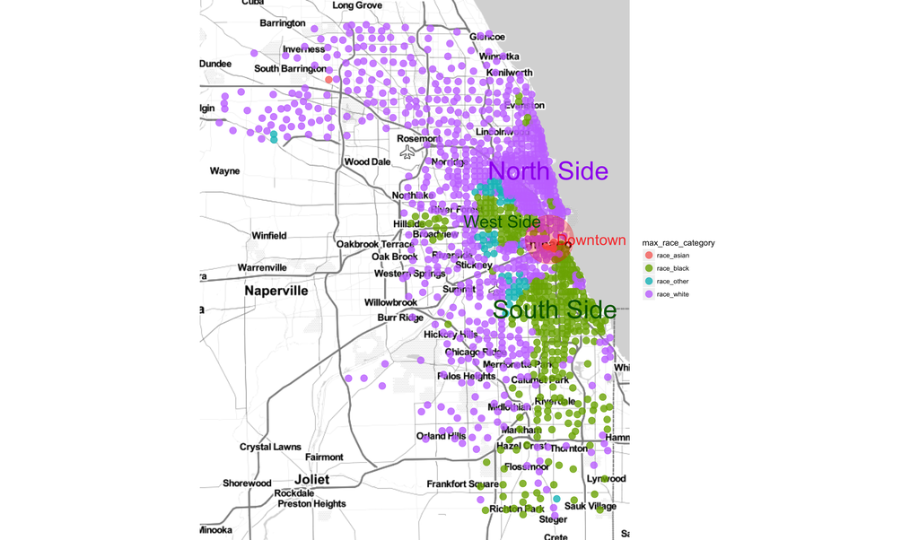

## The Wealth Divide

Chicago has, for a long time, been known for having some of the worst and most violent neighborhoods in the country. For years, headlines about the city of Chicago have been dominated by crime, shootings, and the lost lives of innocent children, much of which can be traced back to poverty.

The racial divide in Chicago has also, inevitably, lead to a divide in wealth as well. Decades of government policies have been put in place to try and undo the segregation that has affected the wealth divide and inequality surrounding Chicago. Suburbs with predominantly black neighborhoods have been held down by overpopulation and public inequity, causing the divide in income to widen even further. White suburbs have long had access to safe and growing neighborhoods and highways to get there.

The following graph show how astonishing the income divide in Chicago really is with its segregated neighborhoods. Areas with a population of 10% or less black residents hold significantly more money than those areas with more black residents. Furthermore, when looking at areas with a black population of 85% or more black residents, the lack of wealth is critically lower than areas with less percentage of black residents.

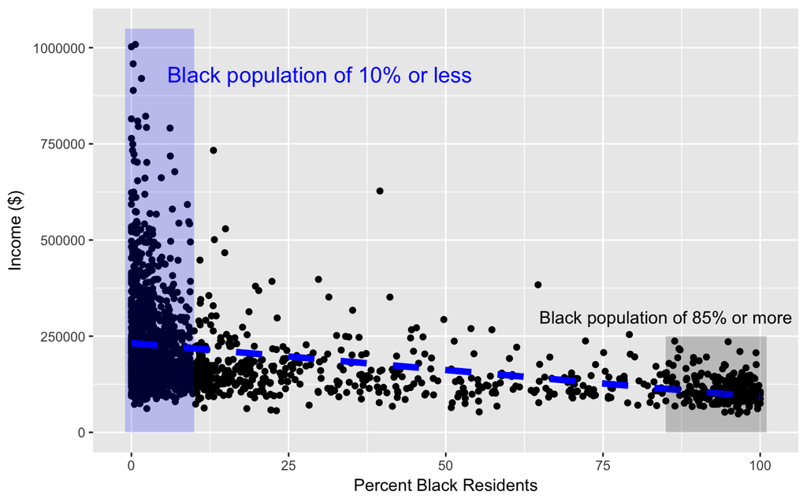

Chicago white households are wealthier than the nation’s average and the city’s African-Americans are significantly less wealthy than the national average (Asante-Muhammad, 17). Children have been (and still are) growing up in neighborhoods that were designed to keep them separated from white children, who are blessed with affluence and opportunity that many black children will never know.

The gini coefficient has long been used to measure inequality in income or wealth. A high gini coefficient represents a large dispersion in income, while a low gini shows a similarity and low deviation in income among residents. We can first note that Chicago as a whole experiences higher wealth inequality than the US average. When looking at the gini coefficient among different income classes, we can see that the largest deviations in income come from the poorest neighborhoods and the smallest deviation occurs in the middle income families.

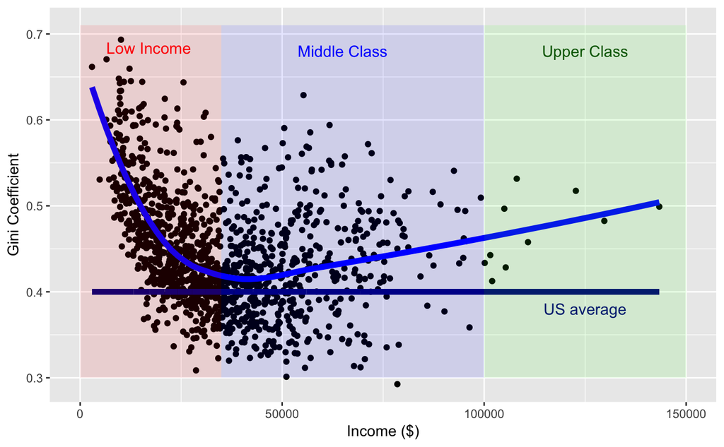

## Conclusion

The racial divide in Chicago and its suburbs is not only very significant, but also very consequential. The physical divide of the city has caused a further divide in its wealth, as well as other inequalities that have become normal many Chicago residents. Many people credit the violence that occurs in Chicago to its poverty and wealth inequalities, while many credit the poverty in the city to its racial segregated upbringings. Can integrating Chicago’s communities help close the gap in Chicago’s wealth divide? Can it make the streets of Chicago less violent and safer for children to grow up and get their education?

It probably wouldn’t be a bad place to start.

#### References

Dedrick Asante-Muhammad, the director of the Racial Wealth Divide Initiative of the nonprofit group, which did the study with a grant from JP Morgan - Cited by Chicago Tribune

Sarah Nasr - AJ+